# Exploring Crime and Socioeconomic Patterns in Malaysia

Hanif Rosdi

2025-12-17

# Setup chunk: global options

```r
knitr::opts_chunk$set(echo = TRUE, message = FALSE, warning = FALSE)
```

1. Introduction

This report explores crime patterns across Malaysian states and investigates socioeconomic factors such as income and poverty. We aim to provide insights for policymakers and stakeholders on how crime relates to socioeconomic conditions.

2. Load Packages

```r
library(tidyverse)
library(janitor)
library(lubridate)
library(scales)
```

3. Load Data

We load the CSV files and clean column names.

```r
crime   <- read_csv("data/crime_district.csv") %>% clean_names()
income  <- read_csv("data/income_state.csv") %>% clean_names()
poverty <- read_csv("data/poverty_state.csv") %>% clean_names()
sex     <- read_csv("data/state_sex.csv") %>% clean_names()
```

4. Inspect Data

Check column names, structure, and missing values.

```r
names(crime); names(income); names(poverty); names(sex)
```

```
## [1] "state"    "district" "category" "type"     "date"     "crimes"
```

```
## [1] "state"         "date"          "income_mean"   "income_median"
```

```
## [1] "state"            "date"             "poverty_absolute" "poverty_hardcore"
## [5] "poverty_relative"
```

```
##  [1] "state"         "sex"           "date"          "lf"
##  [5] "lf_employed"   "lf_unemployed" "lf_outside"    "p_rate"
##  [9] "u_rate"        "ep_ratio"
```

```r
glimpse(crime); glimpse(income); glimpse(poverty); glimpse(sex)
```

```
## Rows: 19,152
## Columns: 6
## $ state    <chr> "Malaysia", "Malaysia", "Malaysia", "Malaysia", "Malaysia", "…
## $ district <chr> "All", "All", "All", "All", "All", "All", "All", "All", "All"…
## $ category <chr> "assault", "assault", "assault", "assault", "assault", "assau…
## $ type     <chr> "all", "all", "all", "all", "all", "all", "all", "all", "caus…
## $ date     <date> 2016-01-01, 2017-01-01, 2018-01-01, 2019-01-01, 2020-01-01, …
## $ crimes   <dbl> 22327, 21366, 16902, 16489, 13279, 11495, 10348, 10453, 5531,…
```

```
## Rows: 303
## Columns: 4
## $ state         <chr> "Johor", "Johor", "Johor", "Johor", "Johor", "Johor", "J…
## $ date          <date> 1970-01-01, 1974-01-01, 1976-01-01, 1979-01-01, 1984-01…
## $ income_mean   <dbl> 237, 382, 513, 731, 1065, 1060, 1150, 1713, 2138, 2772, …
## $ income_median <dbl> NA, 269, 370, 518, 793, 816, 880, 1225, 1610, 2056, 2012…
```

```
## Rows: 294
## Columns: 5
## $ state            <chr> "Johor", "Johor", "Johor", "Johor", "Johor", "Johor",…
## $ date             <date> 1970-01-01, 1976-01-01, 1979-01-01, 1984-01-01, 1987…
## $ poverty_absolute <dbl> 45.7, 29.0, 18.2, 12.2, 11.1, 10.1, 5.6, 3.1, 1.6, 2.…
## $ poverty_hardcore <dbl> NA, NA, NA, 3.1, 2.6, 1.5, 1.1, 0.5, 0.3, 0.4, 0.2, 0…
## $ poverty_relative <dbl> NA, NA, NA, NA, NA, NA, NA, 16.1, 15.8, 15.6, 16.1, 1…
```

```
## Rows: 1,732
## Columns: 10
## $ state         <chr> "Johor", "Johor", "Johor", "Johor", "Johor", "Johor", "J…
## $ sex           <chr> "both", "both", "both", "both", "both", "both", "both", …
## $ date          <date> 1982-01-01, 1983-01-01, 1984-01-01, 1985-01-01, 1986-01…
## $ lf            <dbl> 653.1, 650.9, 688.2, 710.4, 751.2, 781.8, 837.0, 861.8, …
## $ lf_employed   <dbl> 630.2, 623.7, 657.3, 672.7, 700.4, 732.7, 792.0, 822.3, …
## $ lf_unemployed <dbl> 22.9, 27.2, 30.9, 37.6, 50.8, 49.1, 45.1, 39.5, 35.1, 21…
## $ lf_outside    <dbl> 345.1, 344.1, 372.1, 354.7, 367.8, 380.1, 396.5, 439.4, …
## $ p_rate        <dbl> 65.4, 65.4, 64.9, 66.7, 67.1, 67.3, 67.9, 66.2, 67.9, 67…
## $ u_rate        <dbl> 3.5, 4.2, 4.5, 5.3, 6.8, 6.3, 5.4, 4.6, 3.7, 2.2, 2.9, 2…
## $ ep_ratio      <dbl> 63.4, 60.5, 61.7, 61.2, 61.7, 62.6, 65.7, 66.3, 71.6, 68…
```

```r
head(crime); head(income); head(poverty); head(sex)
```

```
## # A tibble: 6 × 6
##   state    district category type  date       crimes
##   <chr>    <chr>    <chr>    <chr> <date>      <dbl>
## 1 Malaysia All      assault  all   2016-01-01  22327
## 2 Malaysia All      assault  all   2017-01-01  21366
## 3 Malaysia All      assault  all   2018-01-01  16902
## 4 Malaysia All      assault  all   2019-01-01  16489
## 5 Malaysia All      assault  all   2020-01-01  13279
## 6 Malaysia All      assault  all   2021-01-01  11495
```

```
## # A tibble: 6 × 4
##   state date       income_mean income_median
##   <chr> <date>           <dbl>         <dbl>
## 1 Johor 1970-01-01         237            NA
## 2 Johor 1974-01-01         382           269
## 3 Johor 1976-01-01         513           370
## 4 Johor 1979-01-01         731           518
## 5 Johor 1984-01-01        1065           793
## 6 Johor 1987-01-01        1060           816
```

```
## # A tibble: 6 × 5
##   state date       poverty_absolute poverty_hardcore poverty_relative
##   <chr> <date>                <dbl>            <dbl>            <dbl>
## 1 Johor 1970-01-01             45.7             NA                 NA
## 2 Johor 1976-01-01             29               NA                 NA
## 3 Johor 1979-01-01             18.2             NA                 NA
## 4 Johor 1984-01-01             12.2              3.1               NA
## 5 Johor 1987-01-01             11.1              2.6               NA
## 6 Johor 1989-01-01             10.1              1.5               NA
```

```
## # A tibble: 6 × 10
##   state sex   date          lf lf_employed lf_unemployed lf_outside p_rate
##   <chr> <chr> <date>     <dbl>       <dbl>         <dbl>      <dbl>  <dbl>
## 1 Johor both  1982-01-01  653.        630.          22.9       345.   65.4
## 2 Johor both  1983-01-01  651.        624.          27.2       344.   65.4
## 3 Johor both  1984-01-01  688.        657.          30.9       372.   64.9
## 4 Johor both  1985-01-01  710.        673.          37.6       355.   66.7
## 5 Johor both  1986-01-01  751.        700.          50.8       368.   67.1
## 6 Johor both  1987-01-01  782.        733.          49.1       380.   67.3
## # ℹ 2 more variables: u_rate <dbl>, ep_ratio <dbl>
```

```r
sapply(crime, function(x) sum(is.na(x)))
```

```
##    state district category     type     date   crimes
##        0        0        0        0        0        0
```

```r
sapply(income, function(x) sum(is.na(x)))
```

```
##         state          date   income_mean income_median
##             0             0             0            11
```

```r
sapply(poverty, function(x) sum(is.na(x)))
```

```
##            state             date poverty_absolute poverty_hardcore
##                0                0                2               39
## poverty_relative
##               93
```

```r
sapply(sex, function(x) sum(is.na(x)))
```

```
##         state           sex          date            lf   lf_employed
##             0             0             0             0             0
## lf_unemployed    lf_outside        p_rate        u_rate      ep_ratio
##             0             0             0             0             0
```

5. Data Cleaning

```r
income$income_median[is.na(income$income_median)] <- median(income$income_mean, na.rm = TRUE)
```

# Create output folders

```r
dir.create("outputs/figures", recursive = TRUE, showWarnings = FALSE)
dir.create("outputs/tables", recursive = TRUE, showWarnings = FALSE)
```

6. Aggregate Data

Aggregate crime per state-year and socioeconomic indicators.

# Crime per state-year

```r
crime_state <- crime %>%
mutate(year = year(ymd(date)), total_crime = crimes) %>%
group_by(state, year) %>%
summarise(total_crime = sum(total_crime, na.rm = TRUE), .groups = "drop")
```

# State-level socioeconomic indicators

```r
income_state <- income %>%
group_by(state) %>%
summarise(median_income = mean(income_median, na.rm = TRUE), .groups = "drop")
```

```r
poverty_state <- poverty %>%
group_by(state) %>%
summarise(poverty_rate = mean(poverty_relative, na.rm = TRUE), .groups = "drop")
```

# Merge datasets

```r
combined <- crime_state %>%
left_join(income_state, by = "state") %>%
left_join(poverty_state, by = "state") %>%
filter(!is.na(total_crime), !is.na(median_income), !is.na(poverty_rate))
```

# State-level summary

```r
state_summary <- combined %>%
group_by(state) %>%
summarise(
avg_crime = mean(total_crime),
avg_income = mean(median_income),
avg_poverty = mean(poverty_rate),
.groups = "drop"
)
```

```r
write_csv(state_summary, "outputs/tables/state_summary.csv")
```

7. Visualizations 7.1 Average Crime by State

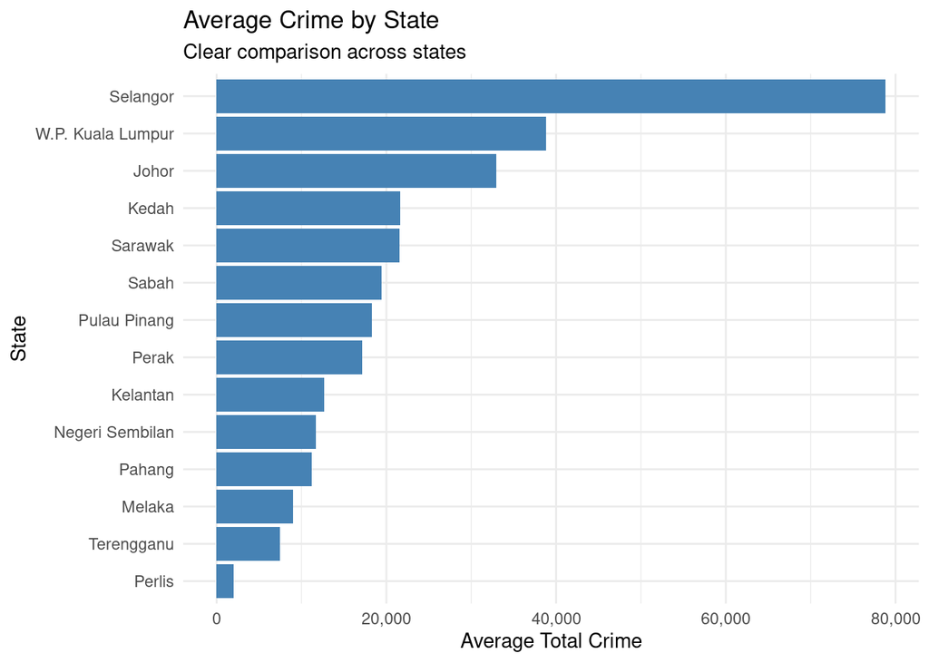

```r
p1 <- ggplot(state_summary, aes(x = reorder(state, avg_crime), y = avg_crime)) +
geom_col(fill = "steelblue") +
coord_flip() +
scale_y_continuous(labels = comma) +
labs(title = "Average Crime by State",
subtitle = "Clear comparison across states",
x = "State",
y = "Average Total Crime") +
theme_minimal()
p1
```

```r
ggsave("outputs/figures/01_avg_crime_by_state.png", p1, width = 9, height = 6)
```

7.2 Crime vs Income (Quadrant)

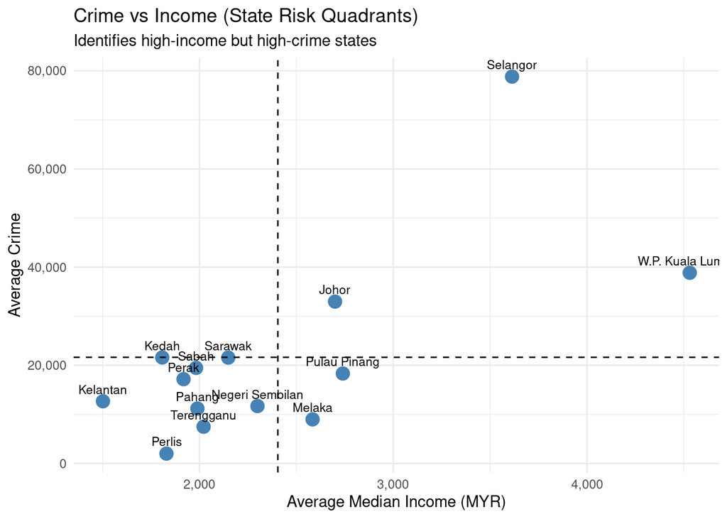

```r
p2 <- ggplot(state_summary, aes(x = avg_income, y = avg_crime)) +
geom_point(size = 4, color = "steelblue") +
geom_vline(xintercept = mean(state_summary$avg_income), linetype = "dashed") +
geom_hline(yintercept = mean(state_summary$avg_crime), linetype = "dashed") +
geom_text(aes(label = state), vjust = -0.8, size = 3) +
scale_x_continuous(labels = comma) +
scale_y_continuous(labels = comma) +
labs(title = "Crime vs Income (State Risk Quadrants)",
subtitle = "Identifies high-income but high-crime states",
x = "Average Median Income (MYR)",
y = "Average Crime") +
theme_minimal()
p2
```

```r
ggsave("outputs/figures/02_crime_vs_income_quadrant.png", p2, width = 9, height = 6)
```

7.3 Crime vs Poverty (Quadrant)

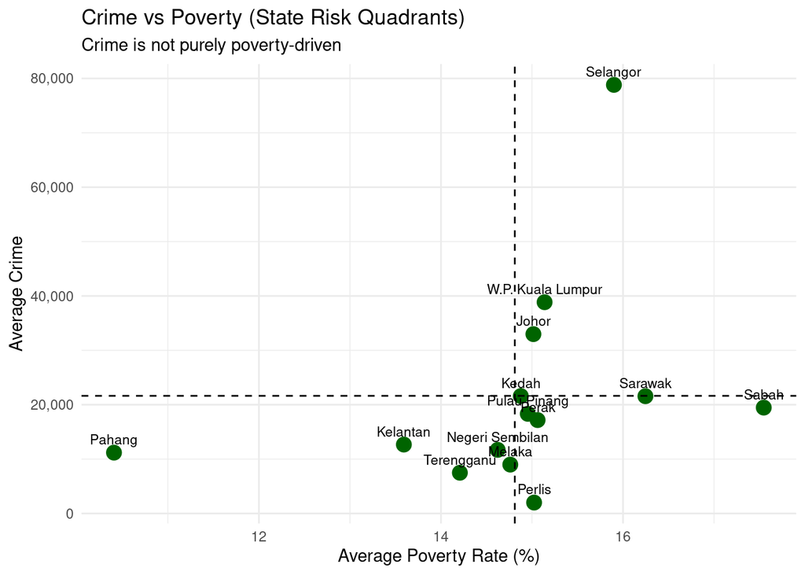

```r
p3 <- ggplot(state_summary, aes(x = avg_poverty, y = avg_crime)) +
geom_point(size = 4, color = "darkgreen") +
geom_vline(xintercept = mean(state_summary$avg_poverty), linetype = "dashed") +
geom_hline(yintercept = mean(state_summary$avg_crime), linetype = "dashed") +
geom_text(aes(label = state), vjust = -0.8, size = 3) +
scale_y_continuous(labels = comma) +
labs(title = "Crime vs Poverty (State Risk Quadrants)",
subtitle = "Crime is not purely poverty-driven",
x = "Average Poverty Rate (%)",
y = "Average Crime") +
theme_minimal()
p3
```

```r
ggsave("outputs/figures/03_crime_vs_poverty_quadrant.png", p3, width = 9, height = 6)
```

7.4 Crime Trends Over Time

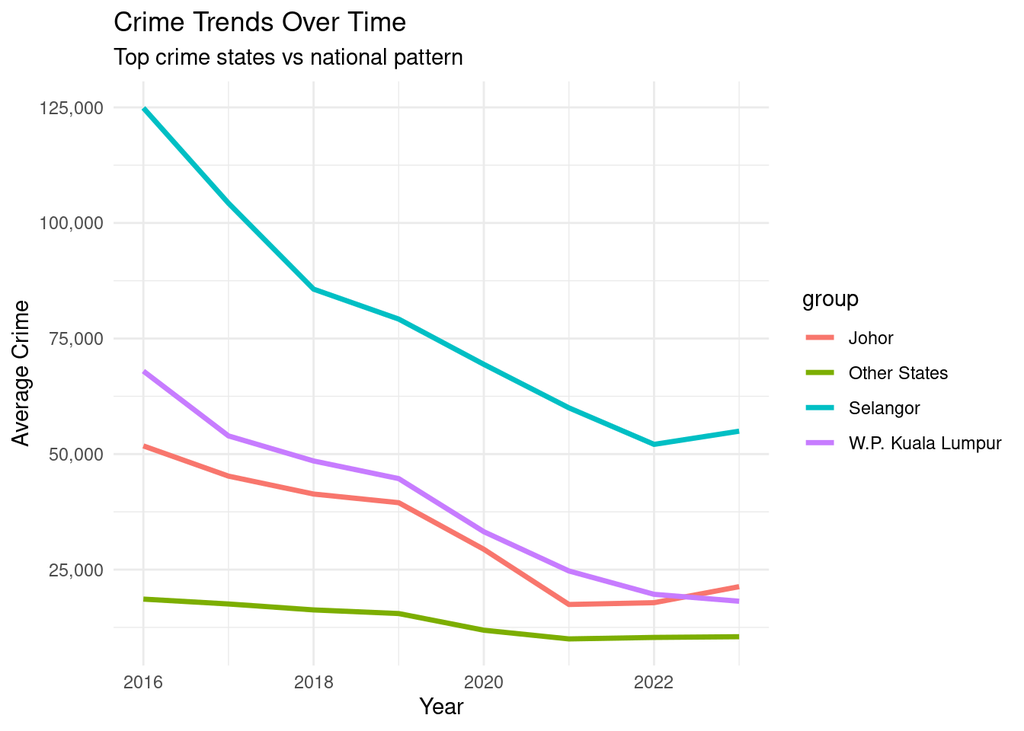

```r
top_states <- state_summary %>%
arrange(desc(avg_crime)) %>%
slice_head(n = 3) %>%
pull(state)

trend_data <- combined %>%
mutate(group = ifelse(state %in% top_states, state, "Other States"))

p4 <- ggplot(trend_data, aes(x = year, y = total_crime, color = group)) +
stat_summary(fun = mean, geom = "line", linewidth = 1.2) +
scale_y_continuous(labels = comma) +
labs(title = "Crime Trends Over Time",
subtitle = "Top crime states vs national pattern",
x = "Year",
y = "Average Crime") +
theme_minimal()
p4
```

```r
ggsave("outputs/figures/04_crime_trends_top_vs_others.png", p4, width = 10, height = 6)
```

7.5 High Crime Despite Good Socioeconomic Conditions

```r
high_crime_good_conditions <- state_summary %>%
filter(avg_crime > mean(avg_crime),
avg_income > mean(avg_income) | avg_poverty < mean(avg_poverty)) %>%
arrange(desc(avg_crime))

write_csv(high_crime_good_conditions, "outputs/tables/high_crime_good_indicators.csv")
high_crime_good_conditions
```

```
## # A tibble: 3 × 4
##   state             avg_crime avg_income avg_poverty
##   <chr>                 <dbl>      <dbl>       <dbl>
## 1 Selangor             78814.      3613.        15.9
## 2 W.P. Kuala Lumpur    38850.      4531.        15.1
## 3 Johor                32982.      2700.        15.0
```

7.6 Correlation Analysis

```r
cor_data <- state_summary %>%
select(avg_crime, avg_income, avg_poverty)

cor_matrix <- cor(cor_data, use = "complete.obs")
round(cor_matrix, 2)
```

```
##             avg_crime avg_income avg_poverty
## avg_crime        1.00       0.69        0.32
## avg_income       0.69       1.00        0.21
## avg_poverty      0.32       0.21        1.00
```

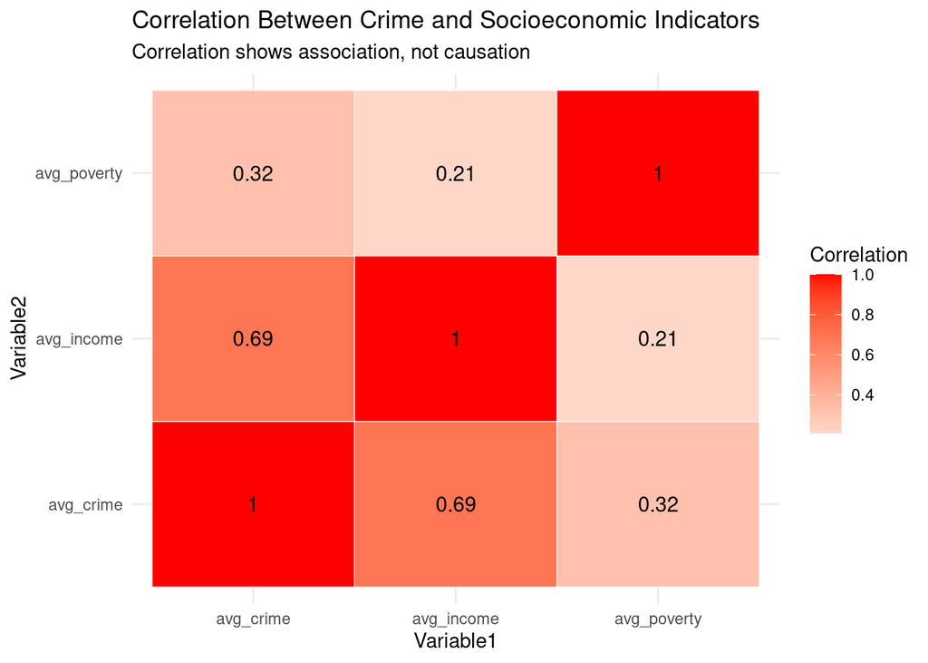

```r
write_csv(as.data.frame(round(cor_matrix,2)), "outputs/tables/correlation_matrix.csv")

# Prepare heatmap

cor_df <- cor_data %>%
cor(use = "complete.obs") %>%
as.data.frame() %>%
rownames_to_column("Variable1") %>%
pivot_longer(-Variable1, names_to = "Variable2", values_to = "Correlation")

p_cor <- ggplot(cor_df, aes(Variable1, Variable2, fill = Correlation)) +
geom_tile(color = "white") +
geom_text(aes(label = round(Correlation, 2)), size = 4) +
scale_fill_gradient2(low = "blue", mid = "white", high = "red", midpoint = 0) +
labs(title = "Correlation Between Crime and Socioeconomic Indicators",
subtitle = "Correlation shows association, not causation") +
theme_minimal()
p_cor
```

```r
ggsave("outputs/figures/05_correlation_heatmap.png", p_cor, width = 7, height = 6)
```

8. Conclusion

High income is moderately correlated with high crime, but this does not imply causation.

Factors likely include urbanization, population density, reporting intensity, and policing coverage.

Socioeconomic patterns provide context but cannot fully explain crime distribution across states.